[figure not shown]

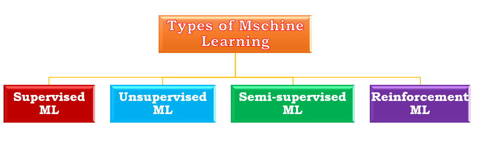

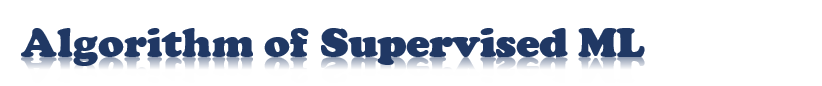

# Logistic Regression

**Logistic regression is a classification algorithm. It is used to predict a binary outcome based on a set of independent variables.**\ **It means a binary outcome is one where there are only two possible scenarios—either the event happens "yes" or it does not happen "No".**

## Used

- **Logistic regression is used to calculate the probability of a binary event occurring, and to deal with issues of classification.**
- **Logistic regression is used to predict the likelihood of all kinds of “yes” or “no” outcomes.**

# K-Nearest Neighbor(KNN)

**K-NN algorithm assumes the similarity between the new case/data and available cases and put the new case**

**into the category that is most similar to the available categories. It stores all the available data and**

**classifies a new data point based on the similarity. This means when new data appears then it can be easily**

**classified into a well suite category by using K- NN algorithm.**

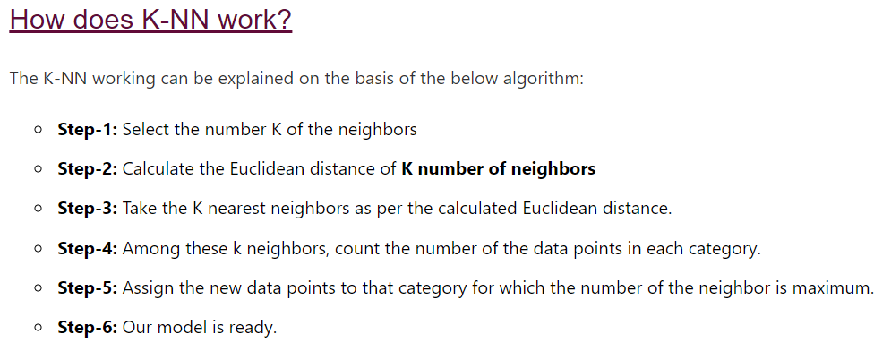

# Support Vector Machine Algorithm

**SVM chooses the extreme points/vectors that help in creating the hyperplane. These extreme cases \ are called as support vectors, and hence algorithm is termed as Support Vector Machine.\ Support Vector Machine or SVM is one of the most popular Supervised Learning algorithms, which is used for\ Classification as well as Regression problems. However, primarily, it is used for Classification problems in Machine Learning.**

# Kernel SVM

**Introduce Kernel functions for sequence data, graphs, text, images, as well as vectors.\ SVM algorithms use a set of mathematical functions that are defined as the kernel. The function\ of kernel is to take data as input and transform it into the required form. Different SVM algorithms\ use different types of kernel functions. These functions can be different types. For example linear,\ nonlinear, polynomial, radial basis function (RBF), and sigmoid.**

# Naive Bayes

**Naive Bayes algorithm is a supervised learning algorithm, which is based on Bayes theorem and used for\ solving classification problems. It is mainly used in text classification that includes a high-dimensional\ training dataset. Naïve Bayes Classifier is one of the simple and most effective Classification algorithms\ which helps in building the fast machine learning models that can make quick predictions.**

- *Naive:* **It is called Naive because it assumes that the occurrence of a certain feature is independent of the occurrence of other features.**
- *Bayes:* **It is called Bayes because it depends on the principle of Bayes' Theorem.**

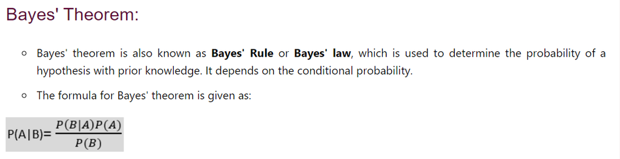

# Decision Tree Classification

**Decision Tree algorithm is one of the simplest yet most powerful Supervised Machine Learning algorithms.\ Decision Tree algorithm can be used to solve both regression and classification problems in Machine Learning.\ That is why it is also known as CART or Classification and Regression Trees. As the name suggests, in Decision\ Tree, we form a tree-like model of decisions and their possible consequences.**

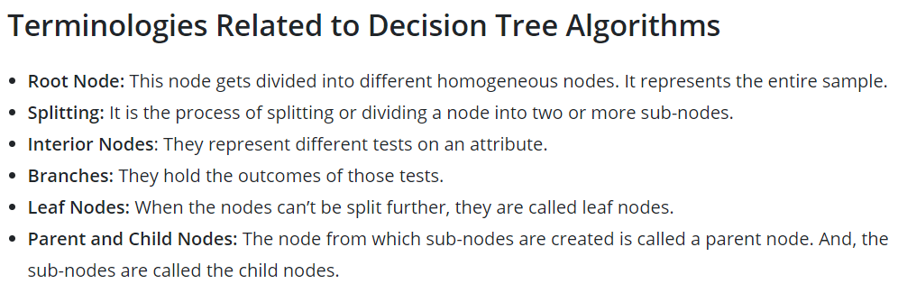

# Random Forest Classification

**Random Forest is a classifier that contains a number of decision trees on various subsets of the given\ dataset and takes the average to improve the predictive accuracy of that dataset.** *Instead of relying on \ one decision tree, the random forest takes the prediction from each tree and based on the majority votes \ of predictions, and it predicts the final output.*

- *The greater number of trees in the forest leads to higher accuracy and prevents the problem of overfitting.*

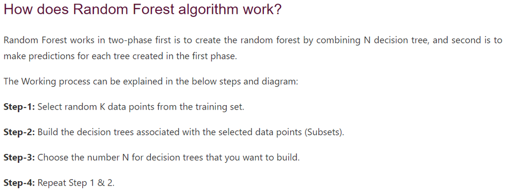

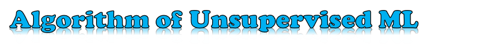

# K-mean Clustring

**It is an iterative algorithm that divides the unlabeled dataset into k different clusters in such a way\ that each dataset belongs only one group that has similar properties.**\ K-Means Clustering is an Unsupervised Learning algorithm, which groups the unlabeled dataset into different\ clusters. Here K defines the number of pre-defined clusters that need to be created in the process, as if K=2,\ there will be two clusters, and for K=3, there will be three clusters, and so on.

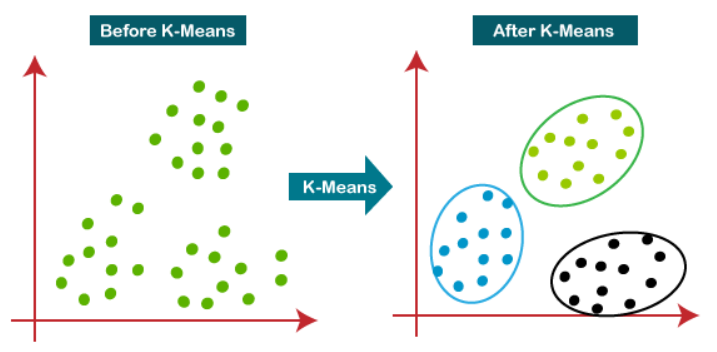

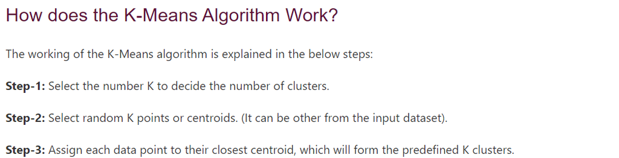

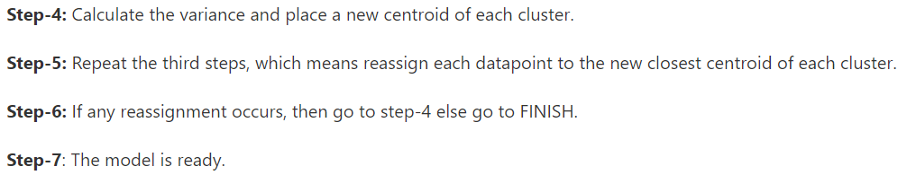

# Hierarchical Clustering

**Hierarchical clustering is another unsupervised machine learning algorithm, which is used to group the \ unlabeled datasets into a cluster and also known as hierarchical cluster analysis or HCA.**

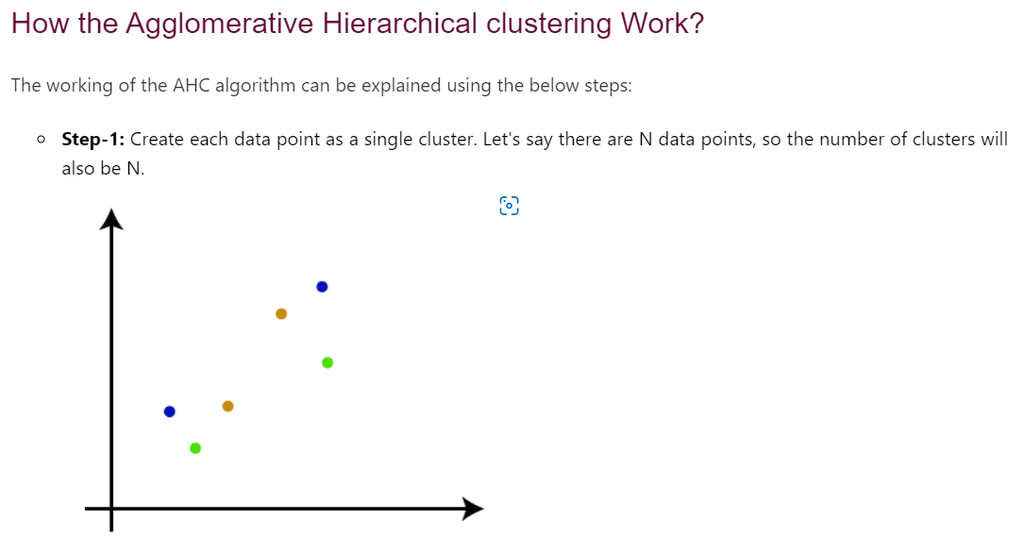

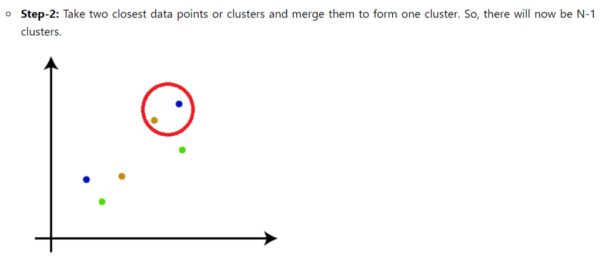

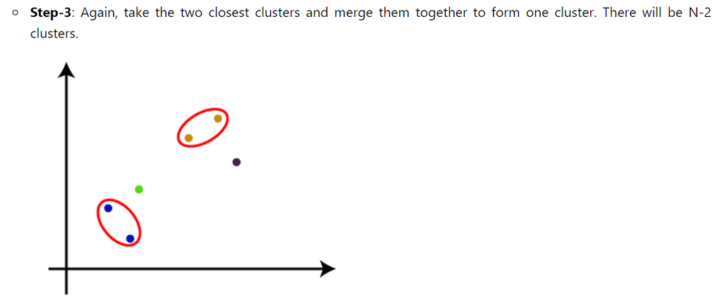

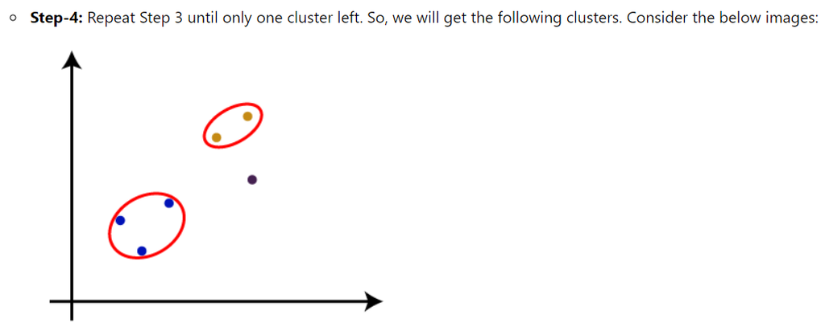

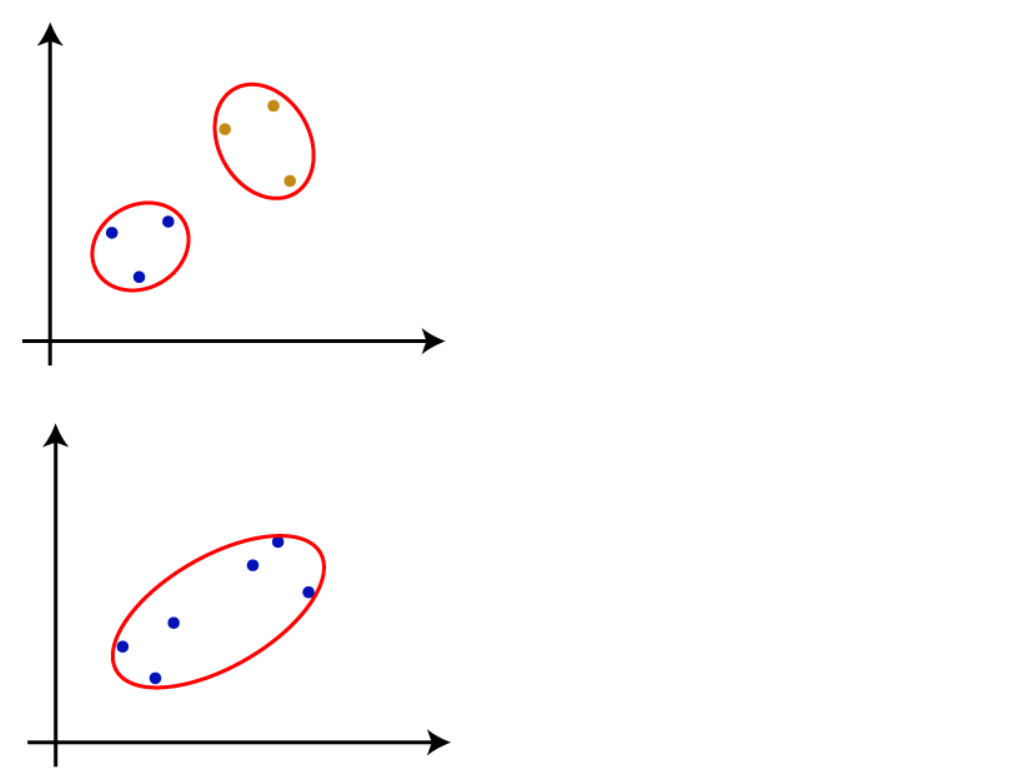

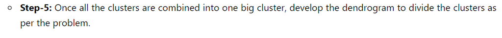

# Model Free Reinforcement Learning

**Model-free reinforcement learning does not need a model for the environment. It helps to learn a \ value function or a policy in a direct manner. The model-free reinforcement learning tends to identify\ situations in which it is a suitable solution.**

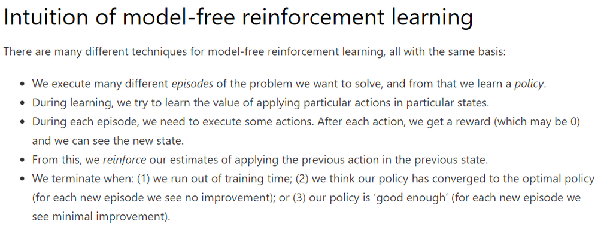

# Model Based Reinforcement Learning

**“Model-based methods rely on planning as their primary component, while model-free methods primarily rely on learning.”**\ Model-based reinforcement learning is that it consists of a model of the environment. The model-based reinforcement learning\ helps to define the probability of ending up in the state t+1 with the current state and action. It is also known as transition\ probability with the explicit function to provide the next state efficiently.

- AI models which are called known models are provided to the agent without any need to go through a training process.
- The agent should learn the model, represented by a neural network, with sufficient and relevant experience.
- **The model-based reinforcement learning consists of an explicit model that needs fewer samples but there \ can be a probability of being inaccurate.**